# Fish Reproduction and Energy Budget in ZooMSS

```r
library(zoomss)
library(ggplot2)
library(patchwork)
library(dplyr)
library(tidyr)
```

```r
# ============================================================================
# MODEL OUTPUT CACHING
# ============================================================================
# Long model runs (>100 years) are cached to avoid re-running on every knit.
# Delete the cache directory to force re-runs.

cache_dir <- here::here("vignettes", "cache")
if (!dir.exists(cache_dir)) dir.create(cache_dir, recursive = TRUE)

#' Run or load a cached ZooMSS model
#'
#' @param cache_name Character name for the cache file (without extension)
#' @param input_params Input parameters for the model
#' @param Groups Functional groups
#' @param isave Save frequency
#' @param cache_dir Path to cache directory (explicit for parallel safety)
#' @param force_rerun Logical, if TRUE, re-run even if cache exists
run_or_load <- function(cache_name, input_params, Groups, isave = 2,
                        energy_budget_scenario = "A", cache_dir, force_rerun = FALSE) {
  cache_file <- file.path(cache_dir, paste0(cache_name, ".rds"))
  if (file.exists(cache_file) && !force_rerun) {
    message("Loading cached model: ", cache_name)
    return(readRDS(cache_file))
  }
  message("Running model: ", cache_name, " (this may take a while...)")
  mdl <- zoomss_model(
    input_params = input_params,
    Groups = Groups,
    isave = isave,
    energy_budget_scenario = energy_budget_scenario
  )
  tmp_file <- tempfile(tmpdir = cache_dir, fileext = ".rds")
  saveRDS(mdl, tmp_file)
  file.rename(tmp_file, cache_file)
  message("Cached model saved: ", cache_file)
  return(mdl)
}
```

## Introduction

This vignette demonstrates the explicit energy budget and fish reproduction system in ZooMSS. The model now implements a DBPM-style (Dynamic Benthic-Pelagic Model) energy budget that explicitly tracks: - **Defecation**: Energy lost as faeces (varies with prey quality) - **Assimilation**: Energy absorbed through the gut wall - **Metabolism**: Energy spent on maintenance (f_M fraction) - **Growth**: Energy allocated to somatic growth (K_growth fraction) - **Reproduction**: Energy allocated to reproductive output (R_frac fraction)

For fish groups with `repro_on = 1`, reproductive investment drives population dynamics through explicit recruitment.

## The Energy Budget Structure

The energy budget follows a two-stage partitioning:

**Stage 1: Ingestion Partitioning**
$$\text{Ingestion} = \text{Defecation} + \text{Assimilation}$$

Where defecation varies continuously based on prey Carbon content:
$$D_{prey} = D_{high} + (D_{low} - D_{high}) \times \left(1 -
\frac{C_{prey}}{C_{max}}\right)$$

This formulation interpolates between low defecation for high-quality (high Carbon) prey and high defecation for low-quality (low Carbon) prey. The approach is based on the Dynamic Benthic-Pelagic Model (DBPM; Blanchard et al. 2009, 2012) which uses two food quality categories (D=0.30 for high quality, D=0.50 for low quality). We extend this to a continuous function using Carbon:wet weight ratio as a proxy for food quality.

**Stage 2: Assimilation Partitioning**
$$\text{Assimilated} = \text{Metabolism} + \text{Growth} +
\text{Reproduction}$$

Where: $f_M + K + R_{frac} = 1$

## Model Setup

Let’s load the default groups and examine the energy budget parameters:

```r
Groups <- getGroups()

# Display energy budget parameters
energy_params <- Groups[, c("Species", "Type", "def_high", "def_low",
                            "f_M", "K_growth", "repro_on", "Carbon")]
print(energy_params)
```

```
#> # A tibble: 12 × 8
#>    Species      Type        def_high def_low   f_M K_growth repro_on Carbon
#>    <chr>        <chr>          <dbl>   <dbl> <dbl>    <dbl>    <dbl>  <dbl>
#>  1 Flagellates  Zooplankton      0.3    0.95  0.45     0.55        0  0.15
#>  2 Ciliates     Zooplankton      0.3    0.95  0.45     0.55        0  0.15
#>  3 Larvaceans   Zooplankton      0.3    0.95  0.4      0.45        0  0.02
#>  4 OmniCopepods Zooplankton      0.3    0.95  0.5      0.3         0  0.12
#>  5 CarnCopepods Zooplankton      0.3    0.95  0.5      0.3         0  0.12
#>  6 Euphausiids  Zooplankton      0.3    0.95  0.55     0.25        0  0.12
#>  7 Chaetognaths Zooplankton      0.3    0.95  0.45     0.35        0  0.04
#>  8 Salps        Zooplankton      0.3    0.95  0.35     0.45        0  0.02
#>  9 Jellyfish    Zooplankton      0.3    0.95  0.3      0.5         0  0.005
#> 10 Fish_Small   Fish             0.3    0.95  0.5      0.3         1  0.1
#> 11 Fish_Med     Fish             0.3    0.95  0.5      0.3         1  0.1
#> 12 Fish_Large   Fish             0.3    0.95  0.5      0.3         1  0.1
```

## Part 1: Constant Environmental Conditions

First, let’s run the model with constant temperature and chlorophyll (1 mg m⁻³) to establish baseline reproduction dynamics. We run for 1000 years to ensure the model reaches an oscillating steady-state, and average over the final 500 years for diagnostics.

```r
# Create constant environmental conditions - 1000 years
env_constant <- createInputParams(
  time = seq(0, 1000, by = 0.1),
  sst = 15,
  chl = 1.0
)
```

```
#> ZooMSS input parameters created:
#> - Time points: 10001 (time values provided)
#> - Time steps: 10000 (intervals to simulate)
#> - Time range: 0 to 1000 years
#> - dt = 0.1 years
#> - SST range: 15 to 15 deg C
#> - Chlorophyll range: 1 to 1 mg/m^3
```

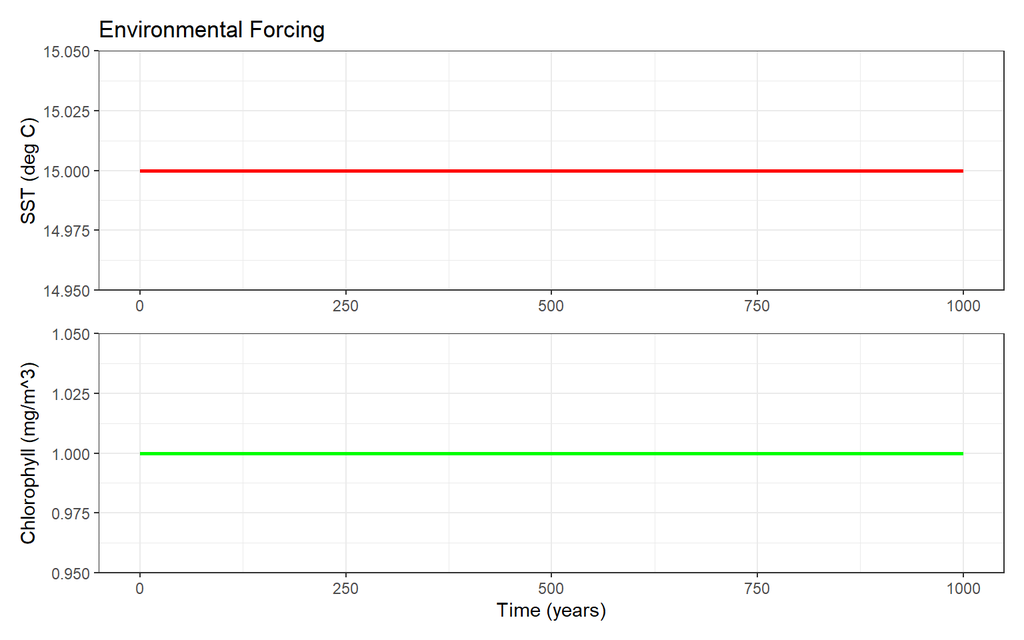

```r
# Plot the environmental forcing
plotEnvironment(env_constant)
```

```r
# Run or load from cache
mdl_constant <- run_or_load("mdl_constant_1000yr", env_constant, Groups, isave = 2, cache_dir = cache_dir)
```

### Visualizing the Energy Budget

Before examining the model dynamics, let’s visualize the energy budget structure.

#### Energy Budget Allocation

This plot shows how assimilated energy is partitioned into metabolism, growth, and reproduction for each functional group:

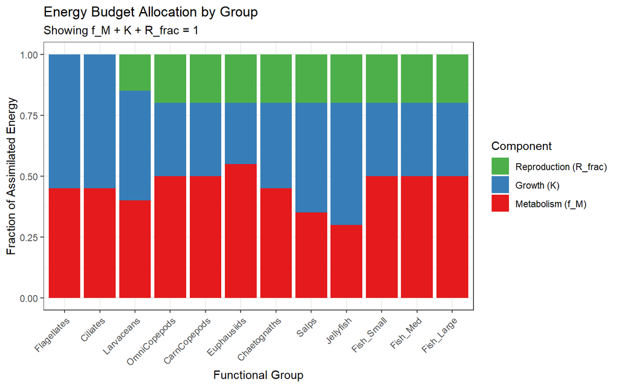

```r
plotEnergyBudget(mdl_constant)
```

#### Defecation by Prey Quality

This plot shows how the defecation fraction experienced by a predator varies depending on the Carbon content of the prey it consumes:

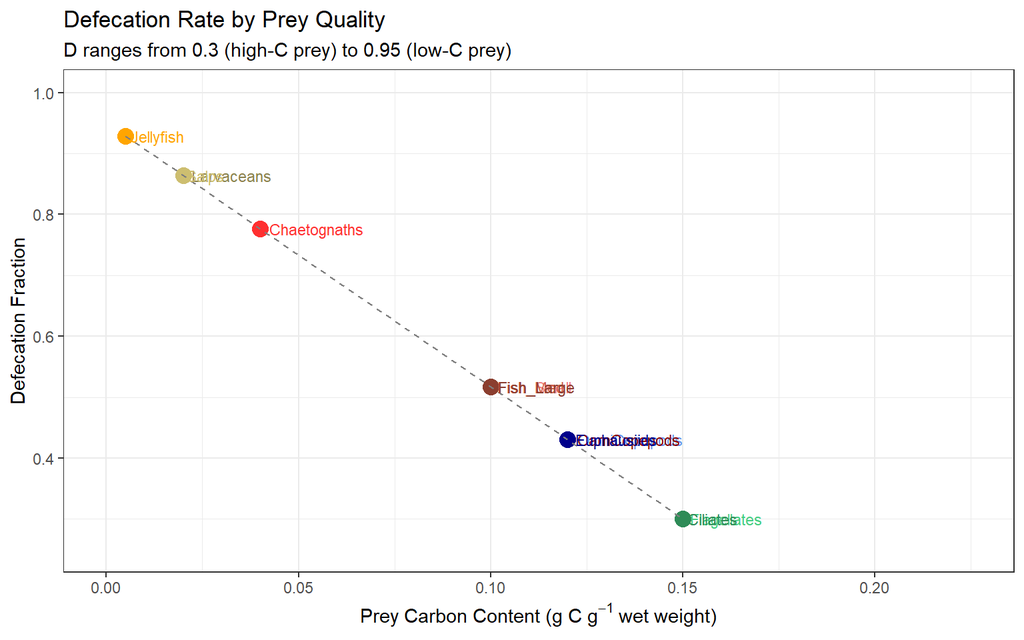

```r
plotDefecation(mdl_constant)
```

When a predator consumes high-Carbon prey (e.g. ciliates at 0.15 g C/g WW), a larger proportion of the ingested material is nutritionally useful, resulting in low defecation (~30%). Conversely, when consuming low-Carbon prey such as gelatinous organisms (e.g. jellyfish at 0.005 g C/g WW), the high water content means most of the ingested material passes through as waste, resulting in high defecation (~95%). The defecation fraction scales linearly between these bounds ($D_{high}$ = 0.30 and $D_{low}$ = 0.95) as a function of the prey’s Carbon:wet weight ratio relative to the maximum across all groups.

#### Prey-Specific Growth Efficiency Matrix

This heatmap shows the net growth efficiency for each predator-prey combination:

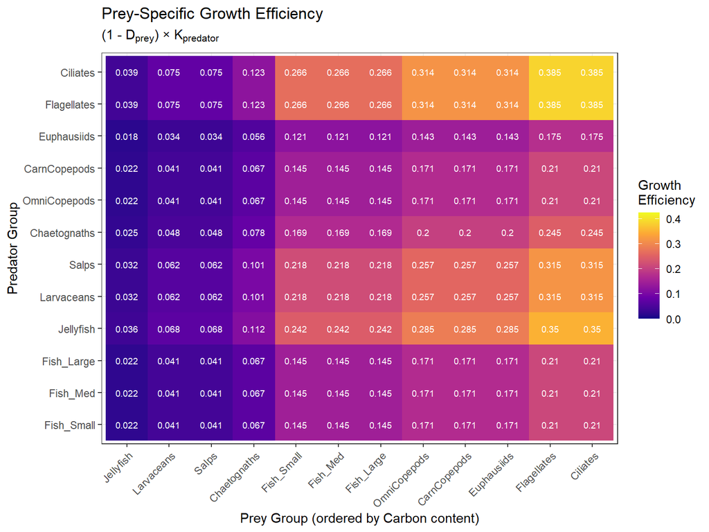

```r
# ==========================================================================
# FIX: The original plotAssimilationMatrix used mdl$assim_by_prey which only
# contains (1 - D_prey). Since def_high/def_low are the same for all groups,
# every row was identical. The true growth efficiency is (1 - D_prey) * K_pred
# which varies by PREDATOR (since K_growth is group-specific).
# ==========================================================================

# Calculate corrected growth efficiency matrix
K_growth_vec <- mdl_constant$param$Groups$K_growth
growth_eff_matrix <- sweep(mdl_constant$assim_by_prey, 1, K_growth_vec, "*")

species <- mdl_constant$param$Groups$Species
carbon <- mdl_constant$param$Groups$Carbon
group_type <- mdl_constant$param$Groups$Type
ngrps <- mdl_constant$param$ngrps

# Order prey by Carbon content (low to high)
prey_order <- species[order(carbon)]

# Order predators by type then Carbon
pred_order <- species[order(group_type, carbon)]

# Convert to long format
assim_long <- expand.grid(predator = species, prey = species)
assim_long$efficiency <- as.vector(growth_eff_matrix)
assim_long$predator <- factor(assim_long$predator, levels = pred_order)
assim_long$prey <- factor(assim_long$prey, levels = prey_order)

ggplot(assim_long, aes(x = prey, y = predator, fill = efficiency)) +
  geom_tile() +
  geom_text(aes(label = round(efficiency, 3)), size = 2.5, colour = "white") +
  scale_fill_viridis_c(option = "plasma", limits = c(0, max(growth_eff_matrix) * 1.1)) +
  theme_bw() +
  theme(axis.text.x = element_text(angle = 45, hjust = 1)) +
  labs(x = "Prey Group (ordered by Carbon content)",
       y = "Predator Group",
       fill = "Growth\nEfficiency",
       title = "Prey-Specific Growth Efficiency",
       subtitle = expression("(1 - D"[prey]*") \u00D7 K"[predator]))
```

### Biomass Dynamics

Let’s examine the biomass dynamics over time:

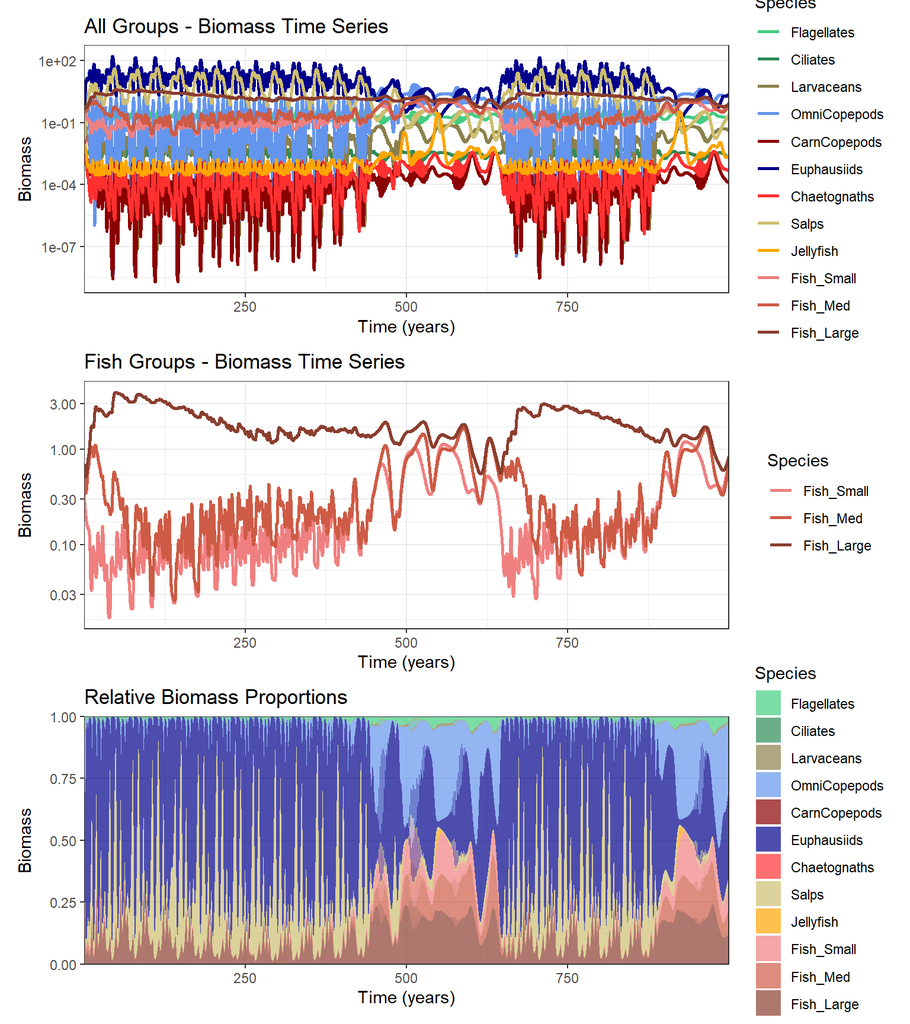

```r
# Plot biomass time series for all groups
p1 <- plotTimeSeries(mdl_constant, by = "biomass", transform = "log10") +
  ggtitle("All Groups - Biomass Time Series")

# Focus on fish groups only
p2 <- plotTimeSeries(mdl_constant, by = "biomass",
                     species = c("Fish_Small", "Fish_Med", "Fish_Large"),
                     transform = "log10") +
  ggtitle("Fish Groups - Biomass Time Series")

# Stacked biomass showing proportions
p3 <- plotTimeSeries(mdl_constant, by = "biomass", type = "fill") +
  ggtitle("Relative Biomass Proportions")

wrap_plots(p1, p2, p3, ncol = 1)
```

### Reproduction Metrics

Now let’s examine the reproduction metrics for fish:

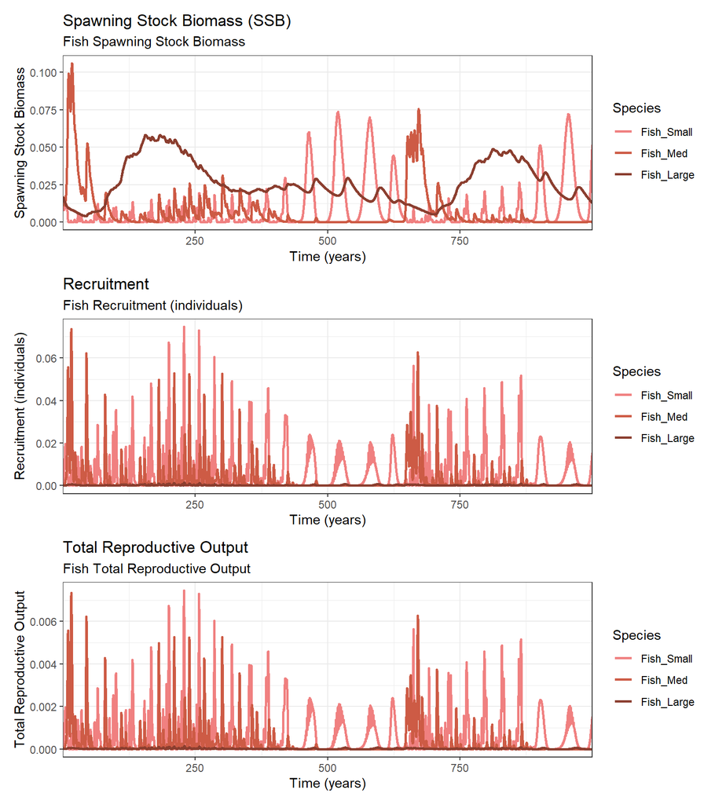

```r
# Spawning Stock Biomass (SSB)
p_ssb <- plotReproduction(mdl_constant, by = "SSB") +
  ggtitle("Spawning Stock Biomass (SSB)")

# Recruitment
p_recruit <- plotReproduction(mdl_constant, by = "recruitment") +
  ggtitle("Recruitment")

# Total reproductive output
p_repro <- plotReproduction(mdl_constant, by = "repro_output") +
  ggtitle("Total Reproductive Output")

wrap_plots(p_ssb, p_recruit, p_repro, ncol = 1)
```

### Stock-Recruitment Relationships

The relationship between Spawning Stock Biomass (SSB) and recruitment is fundamental to understanding fish population dynamics. Let’s examine the emergent stock-recruitment relationships from the model:

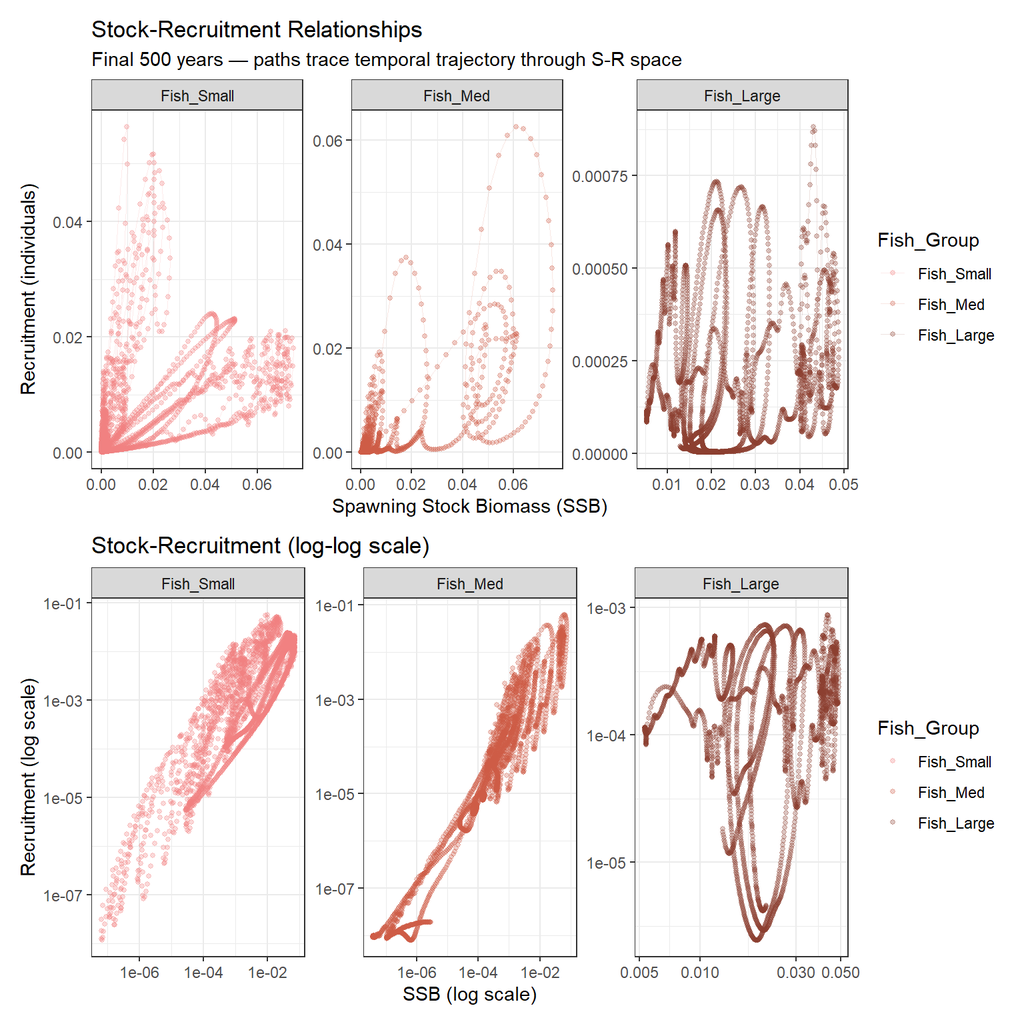

```r
# Extract SSB and recruitment data for stock-recruitment plots
fish_grps <- mdl_constant$param$fish_grps
fish_names <- mdl_constant$param$Groups$Species[fish_grps]
fish_colours <- mdl_constant$param$Groups$PlotColour[fish_grps]
names(fish_colours) <- fish_names

# Use final 500 years of data for steady-state S-R relationships
n_save <- length(mdl_constant$time)
dt_save <- mdl_constant$param$isave * mdl_constant$param$dt
n_500yr <- min(n_save, round(500 / dt_save))
start_idx <- max(1, n_save - n_500yr + 1)

sr_data <- data.frame()
for (f in seq_along(fish_names)) {
  df <- data.frame(
    SSB = mdl_constant$SSB[start_idx:n_save, f],
    Recruitment = mdl_constant$recruitment[start_idx:n_save, f],
    Fish_Group = fish_names[f],
    Time = mdl_constant$time[start_idx:n_save]
  )
  sr_data <- rbind(sr_data, df)
}

sr_data$Fish_Group <- factor(sr_data$Fish_Group, levels = fish_names)

# Stock-recruitment scatter plots
# Points show individual time steps; connecting paths trace the temporal
# trajectory through S-R space (chronological order), revealing the
# oscillatory dynamics as the population cycles between high and low SSB
p_sr <- ggplot(sr_data, aes(x = SSB, y = Recruitment, colour = Fish_Group)) +
  geom_point(alpha = 0.3, size = 1) +
  geom_path(alpha = 0.15, linewidth = 0.3) +
  scale_colour_manual(values = fish_colours) +
  facet_wrap(~Fish_Group, scales = "free") +
  theme_bw() +
  labs(x = "Spawning Stock Biomass (SSB)",
       y = "Recruitment (individuals)",
       title = "Stock-Recruitment Relationships",
       subtitle = "Final 500 years — paths trace temporal trajectory through S-R space")

# SSB vs Recruitment with log axes for comparison
p_sr_log <- ggplot(sr_data %>% filter(SSB > 0 & Recruitment > 0),
                   aes(x = SSB, y = Recruitment, colour = Fish_Group)) +
  geom_point(alpha = 0.3, size = 1) +
  scale_colour_manual(values = fish_colours) +
  scale_x_log10() +
  scale_y_log10() +
  facet_wrap(~Fish_Group, scales = "free") +
  theme_bw() +
  labs(x = "SSB (log scale)",
       y = "Recruitment (log scale)",
       title = "Stock-Recruitment (log-log scale)")

wrap_plots(p_sr, p_sr_log, ncol = 1)
```

The stock-recruitment relationships show the emergent dynamics between spawning biomass and recruitment. In the constant environment, the oscillating steady-state creates characteristic trajectories in S-R space. The connecting paths trace the chronological trajectory — each path follows the population forward through time, revealing how the system orbits through S-R space as SSB and recruitment oscillate out of phase. The relationship is driven by the explicit energy budget where mature fish invest R_frac of their assimilated energy into reproduction, which is then converted to recruits via the reproductive efficiency parameter.